# Practical 8: Supervised Learning

Nina van Gerwen (1860852)

2022-11-02

```r
library(tidyverse)
library(magrittr)
library(psych)
library(caret)
library(gbm)
library(xgboost)
library(data.table)
library(ggforce)
```

## Exploring the data

```r
set.seed(45)
df <- readRDS("data/train_disease.RDS")
```

### 1) Impression of the data

```r
str(df)
```

```
## tibble [500 × 11] (S3: tbl_df/tbl/data.frame)
##  $ Age                       : num [1:500] 58 56 35 51 21 60 48 48 67 36 ...
##  $ Gender                    : Factor w/ 2 levels "Male","Female": 2 1 1 2 1 1 2 2 1 2 ...
##  $ Total_Bilirubin           : num [1:500] 1.7 1 2 0.9 18.5 3.2 1.1 1 2.2 0.7 ...
##  $ Direct_Bilirubin          : num [1:500] 0.8 0.3 1.1 0.2 9.5 1.8 0.7 1.4 1.1 0.2 ...
##  $ Alkaline_Phosphotase      : num [1:500] 1896 195 226 280 380 ...
##  $ Alamine_Aminotransferase  : num [1:500] 61 22 33 21 390 79 178 18 42 21 ...
##  $ Aspartate_Aminotransferase: num [1:500] 83 28 135 30 500 145 250 14 39 25 ...
##  $ Total_Protiens            : num [1:500] 8 5.8 6 6.7 8.2 7.8 8 8.3 7.2 5.9 ...
##  $ Albumin                   : num [1:500] 3.9 2.6 2.7 3.2 4.1 3.2 4.2 4.2 3 3.1 ...
##  $ Ratio_Albumin_Globulin    : num [1:500] 0.95 0.8 0.8 0.8 1 0.69 1.1 1 0.7 1.1 ...
##  $ Disease                   : Factor w/ 2 levels "Healthy","Disease": 1 2 2 1 1 1 1 1 1 2 ...
##  - attr(*, "na.action")= 'omit' Named int [1:4] 210 242 254 313
##   ..- attr(*, "names")= chr [1:4] "210" "242" "254" "313"
```

```r
summary(df)
```

```
##       Age          Gender    Total_Bilirubin  Direct_Bilirubin
##  Min.   : 4.0   Male  :377   Min.   : 0.400   Min.   : 0.100
##  1st Qu.:33.0   Female:123   1st Qu.: 0.800   1st Qu.: 0.200
##  Median :45.0                Median : 1.000   Median : 0.300
##  Mean   :44.6                Mean   : 3.237   Mean   : 1.447
##  3rd Qu.:57.0                3rd Qu.: 2.525   3rd Qu.: 1.200
##  Max.   :90.0                Max.   :75.000   Max.   :19.700
##  Alkaline_Phosphotase Alamine_Aminotransferase Aspartate_Aminotransferase
##  Min.   :  63.0       Min.   :  10.00          Min.   :  10.00
##  1st Qu.: 175.0       1st Qu.:  22.00          1st Qu.:  25.00
##  Median : 208.0       Median :  35.00          Median :  41.00
##  Mean   : 284.6       Mean   :  79.30          Mean   : 107.38
##  3rd Qu.: 292.2       3rd Qu.:  61.25          3rd Qu.:  86.25
##  Max.   :2110.0       Max.   :1680.00          Max.   :4929.00
##  Total_Protiens     Albumin      Ratio_Albumin_Globulin    Disease
##  Min.   :2.700   Min.   :0.900   Min.   :0.3000         Healthy:360
##  1st Qu.:5.800   1st Qu.:2.600   1st Qu.:0.7000         Disease:140
##  Median :6.600   Median :3.100   Median :0.9500
##  Mean   :6.489   Mean   :3.149   Mean   :0.9498
##  3rd Qu.:7.200   3rd Qu.:3.800   3rd Qu.:1.1000
##  Max.   :9.600   Max.   :5.500   Max.   :2.8000
```

```r
describe(df)
```

```
##                            vars   n   mean     sd median trimmed   mad  min
## Age                           1 500  44.60  16.10  45.00   44.59 17.79  4.0
## Gender*                       2 500   1.25   0.43   1.00    1.18  0.00  1.0
## Total_Bilirubin               3 500   3.24   6.23   1.00    1.70  0.44  0.4
## Direct_Bilirubin              4 500   1.45   2.77   0.30    0.72  0.30  0.1
## Alkaline_Phosphotase          5 500 284.58 230.09 208.00  235.63 74.13 63.0
## Alamine_Aminotransferase      6 500  79.30 172.68  35.00   43.38 22.24 10.0
## Aspartate_Aminotransferase    7 500 107.38 279.13  41.00   56.02 29.65 10.0
## Total_Protiens                8 500   6.49   1.10   6.60    6.52  1.04  2.7
## Albumin                       9 500   3.15   0.81   3.10    3.16  0.89  0.9
## Ratio_Albumin_Globulin       10 500   0.95   0.32   0.95    0.93  0.23  0.3
## Disease*                     11 500   1.28   0.45   1.00    1.22  0.00  1.0
##                               max  range  skew kurtosis    se
## Age                          90.0   86.0  0.04    -0.61  0.72
## Gender*                       2.0    1.0  1.18    -0.62  0.02
## Total_Bilirubin              75.0   74.6  5.21    41.31  0.28
## Direct_Bilirubin             19.7   19.6  3.32    12.37  0.12
## Alkaline_Phosphotase       2110.0 2047.0  3.85    19.67 10.29
## Alamine_Aminotransferase   1680.0 1670.0  6.11    43.31  7.72
## Aspartate_Aminotransferase 4929.0 4919.0 11.41   179.38 12.48
## Total_Protiens                9.6    6.9 -0.27     0.14  0.05
## Albumin                       5.5    4.6 -0.04    -0.43  0.04
## Ratio_Albumin_Globulin        2.8    2.5  0.91     2.81  0.01
## Disease*                      2.0    1.0  0.98    -1.05  0.02
```

All looks good!

### 2) Data visualisations

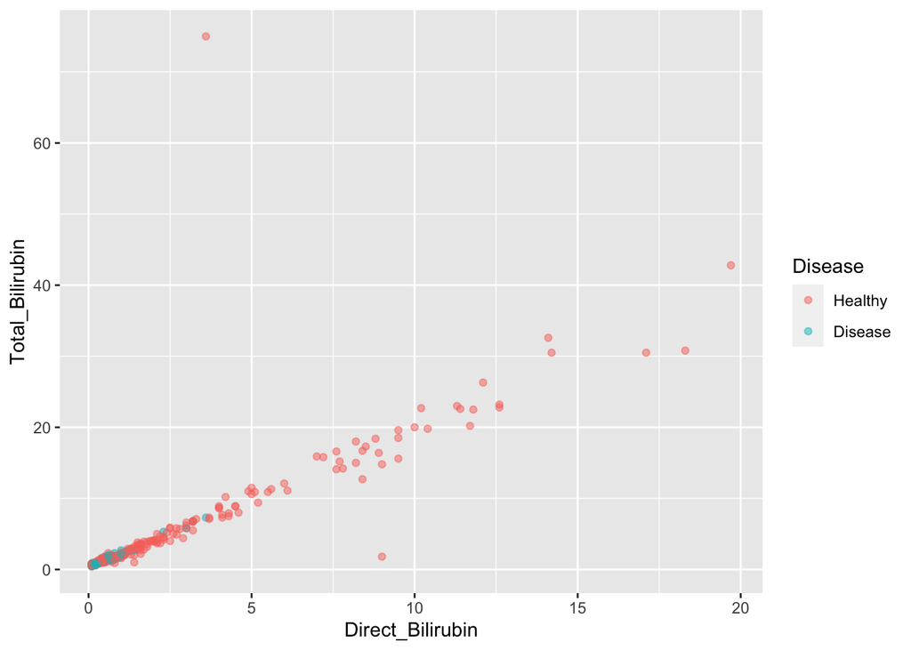

```r
df %>%
  ggplot(., aes(x = Direct_Bilirubin, y = Total_Bilirubin, col = Disease)) +
  geom_point(alpha = .5)
```

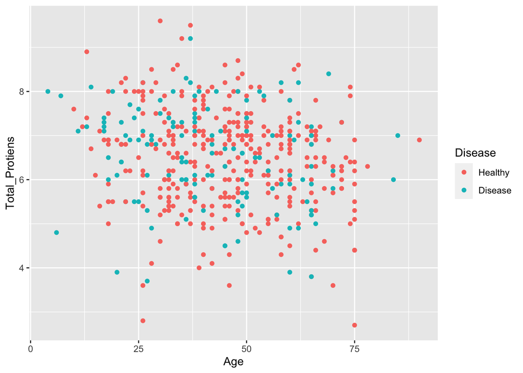

```r
df %>%
  ggplot(., aes(x = Age, y = Total_Protiens, col = Disease)) +
  geom_point()
```

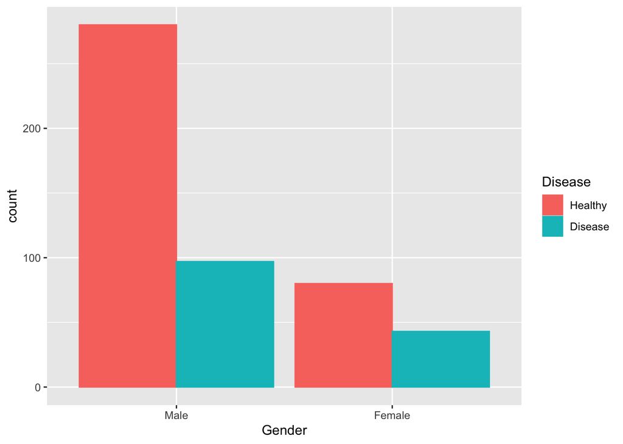

```r
df %>%
  ggplot(., aes(x = Gender, col = Disease, fill = Disease)) +
  geom_bar(position = "dodge")
```

A very linear relation between direct and total bilirubin, to be expected. There does not seem to be a relation between age and total proteins. Furthermore, disease also does not seem to affect total proteins. Looking at gender, we find that women seem to suffer from the disease more often relative to men.

### 3) Bagging, random forests and boosting

The biggest difference between bagging and randomforests vs. boosting is that boosting is a sequential method, whereas the other two are parallel methods. This means that the first model created in a boosting algorithm will affect all models thereafter. In bagging and randomforests, instead, the models are not dependent on previous models.

Then, the difference between bagging and randomforests has to do with the correlations. In a bagging algorithm, the parallel models are correlated with one another, whereas in a randomforest, they have been de-correlated through randomness.

### 4) Applying bagging to the disease data

```r
cvcontrol <- trainControl(method = "repeatedcv",
                          number = 10,
                          allowParallel = TRUE)

trained_bag <- train(Disease ~ ., data = df, method = "treebag",
                     trControl = cvcontrol, importance = TRUE)
```

### 5) Interpreting variable importance

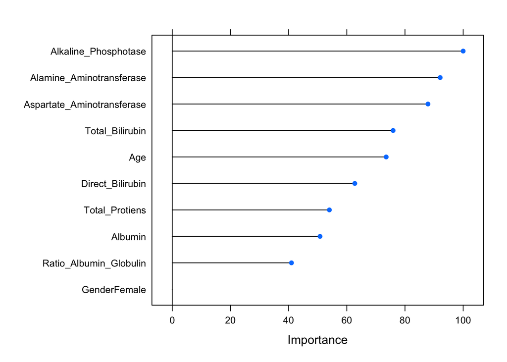

```r
varImp(trained_bag) %>% plot()
```

The bagging method has found that alkaline phosphotase is the most important protein in predicting whether someone will suffer from the disease.

### 6) Creating predictions and assessing performance

```r
confusionMatrix(data = predict(trained_bag, type = "raw"), reference = df$Disease)
```

```
## Confusion Matrix and Statistics
##
##           Reference
## Prediction Healthy Disease
##    Healthy     360       0
##    Disease       0     140
##
##                Accuracy : 1
##                  95% CI : (0.9926, 1)
##     No Information Rate : 0.72
##     P-Value [Acc > NIR] : < 2.2e-16
##
##                   Kappa : 1
##
##  Mcnemar's Test P-Value : NA
##
##             Sensitivity : 1.00
##             Specificity : 1.00
##          Pos Pred Value : 1.00
##          Neg Pred Value : 1.00
##              Prevalence : 0.72
##          Detection Rate : 0.72
##    Detection Prevalence : 0.72
##       Balanced Accuracy : 1.00
##
##        'Positive' Class : Healthy
##
```

The model works perfectly with an Accuracy of 1! There were no false negatives or false positives.

### 7) Outputting the trained bag model

```r
trained_bag
```

```
## Bagged CART
##
## 500 samples
##  10 predictor
##   2 classes: 'Healthy', 'Disease'
##
## No pre-processing
## Resampling: Cross-Validated (10 fold, repeated 1 times)
## Summary of sample sizes: 450, 450, 450, 450, 450, 450, ...
## Resampling results:
##
##   Accuracy  Kappa
##   0.678     0.1311671
```

The accuracy differs (from 1 to 0.678). I am unaware as to why this might be the case. Perhaps the accuracy is for the out-of-bag predictions?

### 8) Fitting a randomforest

```r
trained_forest <- train(Disease ~ ., data = df, method = "rf", trControl = cvcontrol, importance = TRUE)
```

### 9) Assessing variable importance

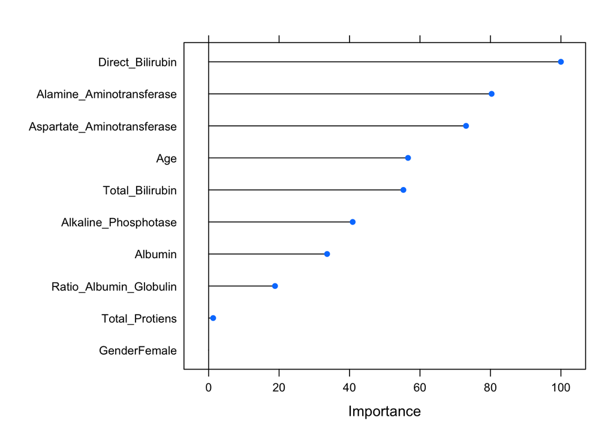

```r
trained_forest %>%
  varImp() %>%
  plot()
```

We get a different result this time! The random forest states that direct-bilirubin is the most important protein in predicting whether someone suffers from the disease. Furthermore, the alkaline phosphotase is much less important this time relative to the other predictors (6th in importance vs. 1st).

### 10) Outputting the model

```r
trained_forest
```

```
## Random Forest
##
## 500 samples
##  10 predictor
##   2 classes: 'Healthy', 'Disease'
##
## No pre-processing
## Resampling: Cross-Validated (10 fold, repeated 1 times)
## Summary of sample sizes: 450, 450, 450, 450, 450, 450, ...
## Resampling results across tuning parameters:
##
##   mtry  Accuracy  Kappa
##    2    0.704     0.1618056
##    6    0.688     0.1540873
##   10    0.690     0.1719310
##
## Accuracy was used to select the optimal model using the largest value.
## The final value used for the model was mtry = 2.
```

When randomly sampling 2 variables as candidates at each split, the accuracy goes up from .678 to .704. So yes, we are doing slightly better than bagging.

### 11) Fitting a boosting model

```r
trained_boost <- train(Disease ~ ., data = df, method = "gbm",
                       trControl = cvcontrol)
```

### 12) Assessing variable importance

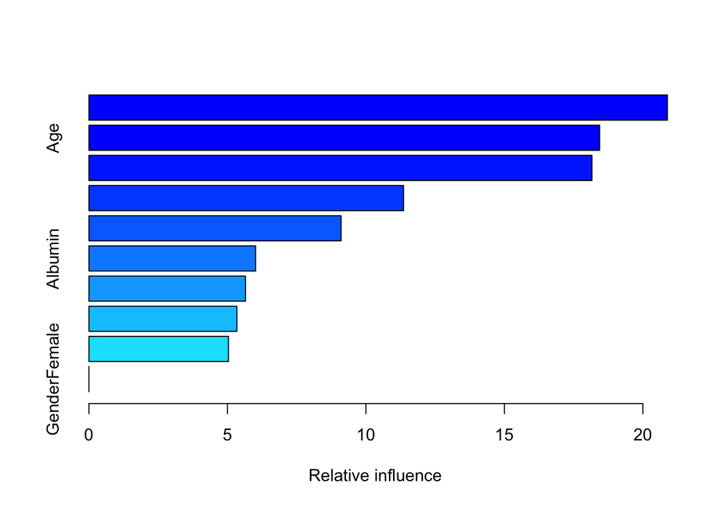

```
##                                                   var   rel.inf
## Aspartate_Aminotransferase Aspartate_Aminotransferase 20.886533
## Age                                               Age 18.439905
## Alkaline_Phosphotase             Alkaline_Phosphotase 18.162142
## Direct_Bilirubin                     Direct_Bilirubin 11.358766
## Alamine_Aminotransferase     Alamine_Aminotransferase  9.103917
## Albumin                                       Albumin  6.016757
## Total_Protiens                         Total_Protiens  5.652463
## Ratio_Albumin_Globulin         Ratio_Albumin_Globulin  5.342127
## Total_Bilirubin                       Total_Bilirubin  5.037390
## GenderFemale                             GenderFemale  0.000000
```

```r
summary(trained_boost)
```

### 13) Outputting the boosting model

```r
trained_boost
```

```
## Stochastic Gradient Boosting
##
## 500 samples
##  10 predictor
##   2 classes: 'Healthy', 'Disease'
##
## No pre-processing
## Resampling: Cross-Validated (10 fold, repeated 1 times)
## Summary of sample sizes: 450, 450, 450, 450, 450, 450, ...
## Resampling results across tuning parameters:
##
##   interaction.depth  n.trees  Accuracy  Kappa
##   1                   50      0.708     0.1117547
##   1                  100      0.712     0.1700777
##   1                  150      0.708     0.1609721
##   2                   50      0.694     0.1084389
##   2                  100      0.680     0.1058856
##   2                  150      0.674     0.1042949
##   3                   50      0.694     0.1252223
##   3                  100      0.694     0.1545466
##   3                  150      0.688     0.1280794
##
## Tuning parameter 'shrinkage' was held constant at a value of 0.1
##
## Tuning parameter 'n.minobsinnode' was held constant at a value of 10
## Accuracy was used to select the optimal model using the largest value.
## The final values used for the model were n.trees = 100, interaction.depth =
##  1, shrinkage = 0.1 and n.minobsinnode = 10.
```

It seems to have similar performance as the random forest and bagging methods.

### 14) Downloading shap.R

```r
library(devtools)
source_url("https://github.com/pablo14/shap-values/blob/master/shap.R?raw=TRUE")
```

```
## ℹ SHA-1 hash of file is "602645f005640081bb3b11b47eab27b730d74dc8"
```

### 15) Specifying a model

```r
train_x <- model.matrix(Disease ~ ., df)[,-1]
train_y <- as.numeric(df$Disease) - 1
xgboost_train <- xgboost(data = train_x,
                         label = train_y,
                         max.depth = 10,
                         eta = 1,
                         nthread = 4,
                         nrounds = 4,
                         objective = "binary:logistic",
                         verbose = 2)
pred <- tibble(Disease = predict(xgboost_train, newdata = train_x)) %>%
  mutate(Disease = factor(ifelse(Disease < 0.5, 1, 2),
                          labels = c("Healthy", "Disease")))

table(pred$Disease, df$Disease)
```

```
##
##           Healthy Disease
##   Healthy     357       6
##   Disease       3     134
```

### 16) Calculating SHAP rank scores and creating a variable importance plot

```r
shap_results <- shap.score.rank(xgboost_train,
                                X_train = train_x,
                                shap_approx = F)
```

```
## make SHAP score by decreasing order
```

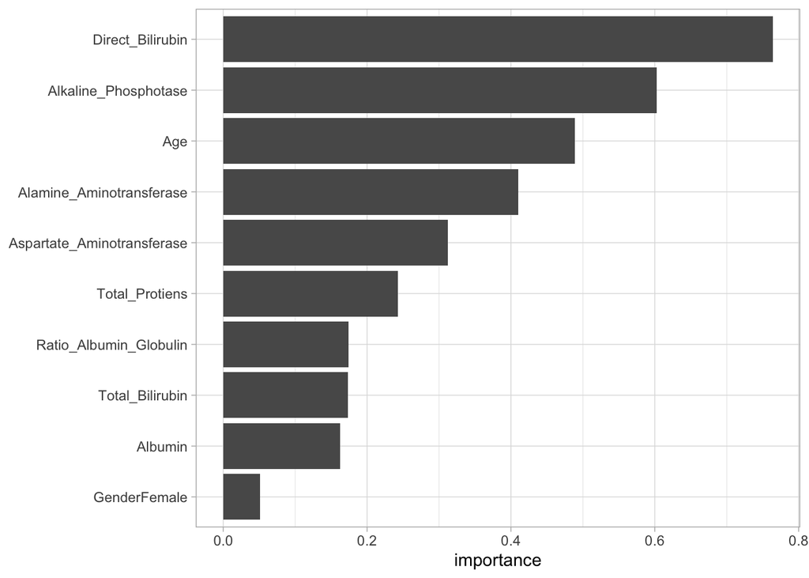

```r
var_importance(shap_results)
```

According to the SHAP rank scores, direct bilirubin is again the most important variable, followed by alkaline phosphotase.

### 17) Plotting the SHAP values for every individual feature

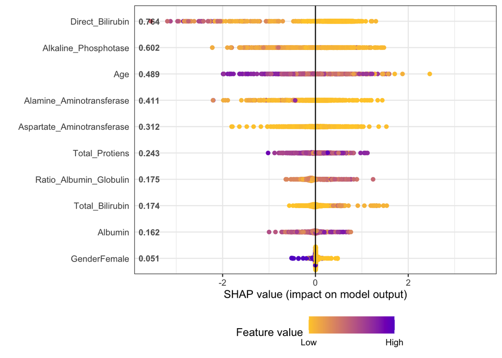

```r
shap_long <- shap.prep(shap = shap_results,
                       X_train = train_x)

plot.shap.summary(shap_long)
```

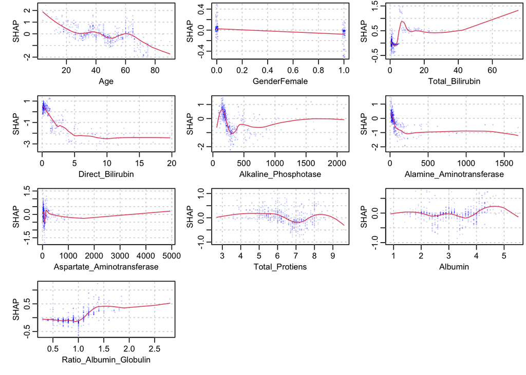

```r
xgb.plot.shap(train_x, features = colnames(train_x), model = xgboost_train, n_col = 3)
```

The first plot shows that people with very low direct bilirubin have a higher probability to have the Disease (i.e., a negative relationship). As for age, it indicates that the higher your age, the less likely to have the disease.

The second plot shows the same, however it is visualised differently. I would not know how to interpret these really.

### 18) Validating the different models on the test data

```r
df_val <- readRDS("data/test_disease.RDS")

bag_pred <- predict(trained_bag, newdata = df_val, type = "raw")
for_pred <- predict(trained_forest, newdata = df_val, type = "raw")
boost_pred <- predict(trained_boost, newdata = df_val, type = "raw")
boost_2_pred <- predict(xgboost_train, newdata = model.matrix(Disease ~ ., df_val)[,-1]) %>%
  factor(x = ifelse(. < 0.5, 1, 2), levels = c(1,2), labels = c("Healthy", "Disease"))

confusionMatrix(bag_pred, df_val$Disease)
```

```
## Confusion Matrix and Statistics
##
##           Reference
## Prediction Healthy Disease
##    Healthy      48      16
##    Disease       6       9
##
##                Accuracy : 0.7215
##                  95% CI : (0.6093, 0.8165)
##     No Information Rate : 0.6835
##     P-Value [Acc > NIR] : 0.27598
##
##                   Kappa : 0.2788
##
##  Mcnemar's Test P-Value : 0.05501
##
##             Sensitivity : 0.8889
##             Specificity : 0.3600
##          Pos Pred Value : 0.7500
##          Neg Pred Value : 0.6000
##              Prevalence : 0.6835
##          Detection Rate : 0.6076
##    Detection Prevalence : 0.8101
##       Balanced Accuracy : 0.6244
##
##        'Positive' Class : Healthy
##
```

```r
confusionMatrix(for_pred, df_val$Disease)
```

```
## Confusion Matrix and Statistics
##
##           Reference
## Prediction Healthy Disease
##    Healthy      52      18
##    Disease       2       7
##
##                Accuracy : 0.7468
##                  95% CI : (0.6364, 0.838)
##     No Information Rate : 0.6835
##     P-Value [Acc > NIR] : 0.1374222
##
##                   Kappa : 0.2934
##
##  Mcnemar's Test P-Value : 0.0007962
##
##             Sensitivity : 0.9630
##             Specificity : 0.2800
##          Pos Pred Value : 0.7429
##          Neg Pred Value : 0.7778
##              Prevalence : 0.6835
##          Detection Rate : 0.6582
##    Detection Prevalence : 0.8861
##       Balanced Accuracy : 0.6215
##
##        'Positive' Class : Healthy
##
```

```r
confusionMatrix(boost_pred, df_val$Disease)
```

```
## Confusion Matrix and Statistics
##
##           Reference
## Prediction Healthy Disease
##    Healthy      54      20
##    Disease       0       5
##
##                Accuracy : 0.7468
##                  95% CI : (0.6364, 0.838)
##     No Information Rate : 0.6835
##     P-Value [Acc > NIR] : 0.1374
##
##                   Kappa : 0.2547
##
##  Mcnemar's Test P-Value : 2.152e-05
##
##             Sensitivity : 1.0000
##             Specificity : 0.2000
##          Pos Pred Value : 0.7297
##          Neg Pred Value : 1.0000
##              Prevalence : 0.6835
##          Detection Rate : 0.6835
##    Detection Prevalence : 0.9367
##       Balanced Accuracy : 0.6000
##
##        'Positive' Class : Healthy
##
```

```r
confusionMatrix(boost_2_pred, df_val$Disease)
```

```
## Confusion Matrix and Statistics
##
##           Reference
## Prediction Healthy Disease
##    Healthy      44      14
##    Disease      10      11
##
##                Accuracy : 0.6962
##                  95% CI : (0.5825, 0.7947)
##     No Information Rate : 0.6835
##     P-Value [Acc > NIR] : 0.4577
##
##                   Kappa : 0.2663
##
##  Mcnemar's Test P-Value : 0.5403
##
##             Sensitivity : 0.8148
##             Specificity : 0.4400
##          Pos Pred Value : 0.7586
##          Neg Pred Value : 0.5238
##              Prevalence : 0.6835
##          Detection Rate : 0.5570
##    Detection Prevalence : 0.7342
##       Balanced Accuracy : 0.6274
##
##        'Positive' Class : Healthy
##
```